# Introduction to Simple Linear Regression

### 3. Homoscedasticity Check

We can create a residual plot (plotting residuals vs. predicted values). If the residuals show no clear pattern (they’re randomly scattered around zero), then the homoscedasticity assumption holds.

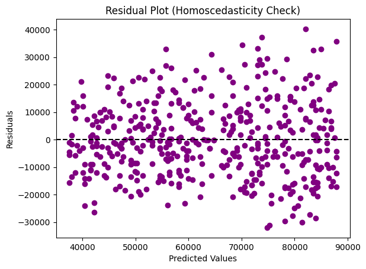

```python
# Calculate residuals
residuals = y_train - train_predictions

# Plot residuals vs. predicted values
plt.scatter(train_predictions, residuals, color='purple')
plt.axhline(y=0, color='black', linestyle='--')
plt.xlabel("Predicted Values")
plt.ylabel("Residuals")
plt.title("Residual Plot (Homoscedasticity Check)")
plt.show()
```

If residuals are randomly scattered around zero with no visible pattern, this suggests homoscedasticity. Patterns (such as a funnel shape) would indicate heteroscedasticity

### 4. Normality of Residuals

To check if the residuals are normally distributed, we can use a histogram and a Q-Q plot. Alternatively, the Shapiro-Wilk test or Kolmogorov-Smirnov test can be used.

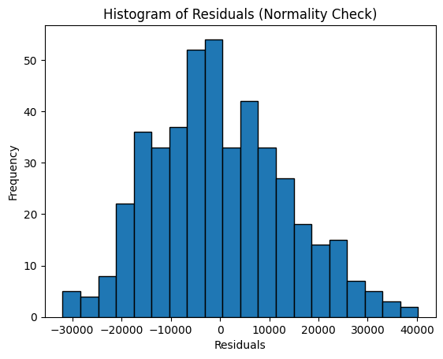

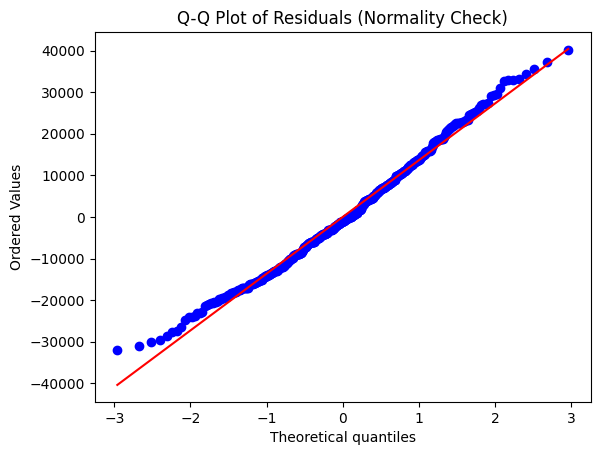

```python
import scipy.stats as stats

# Histogram of residuals
plt.hist(residuals, bins=20, edgecolor='black')
plt.xlabel("Residuals")
plt.ylabel("Frequency")
plt.title("Histogram of Residuals (Normality Check)")
plt.show()

# Q-Q plot
stats.probplot(residuals, dist="norm", plot=plt)
plt.title("Q-Q Plot of Residuals (Normality Check)")
plt.show()
```

If the residuals are approximately normally distributed, the histogram should look bell-shaped, and the points in the Q-Q plot should roughly follow a straight line.

### 5. Multicollinearity Check (Only for Multiple Regression)

For multiple linear regression, multicollinearity among independent variables can be assessed using the Variance Inflation Factor (VIF). A VIF value greater than 10 indicates high multicollinearity.

Since we’re using simple linear regression, this doesn’t apply here. However, if we expand to multiple regression, you can calculate VIF as follows:

```python
""" from statsmodels.stats.outliers_influence import variance_inflation_factor
import statsmodels.api as sm

# Assuming `X` contains all predictors for multiple regression
X = sm.add_constant(df.iloc[:, :-1])  # Add constant term for intercept
vif_data = pd.DataFrame()
vif_data["feature"] = X.columns
vif_data["VIF"] = [variance_inflation_factor(X.values, i) for i in range(X.shape[1])]
print(vif_data)
"""
```

[output not shown]

*References*

- https://www.geeksforgeeks.org/ml-linear-regression/
- https://www.javatpoint.com/simple-linear-regression-in-machine-learning
- https://www.analyticsvidhya.com/blog/2023/01/a-comprehensive-guide-to-ols-regression-part-1/